# Machine Learning

### Boosting

### Ada Boost

```python
from sklearn.ensemble import AdaBoostClassifier
ADB_model = AdaBoostClassifier(n_estimators=100,random_state=1)
ADB_model.fit(x_train,y_train)
```

```
AdaBoostClassifier(n_estimators=100, random_state=1)
```

```python
## Performance Matrix on train data set
y_train_predict = ADB_model.predict(x_train)
model_score = ADB_model.score(x_train, y_train)
print(model_score)
print(metrics.confusion_matrix(y_train, y_train_predict))
print(metrics.classification_report(y_train, y_train_predict))
```

```
0.8501413760603205
[[214  93]
 [ 66 688]]
              precision    recall  f1-score   support

           0       0.76      0.70      0.73       307
           1       0.88      0.91      0.90       754

    accuracy                           0.85      1061
   macro avg       0.82      0.80      0.81      1061
weighted avg       0.85      0.85      0.85      1061
```

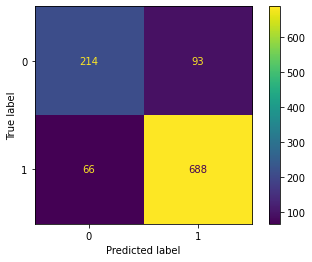

```python
plot_confusion_matrix(ADB_model,x_train,y_train);
```

```python
## Performance Matrix on test data set
y_test_predict = ADB_model.predict(x_test)
model_score = ADB_model.score(x_test, y_test)
print(model_score)
print(metrics.confusion_matrix(y_test, y_test_predict))
print(metrics.classification_report(y_test, y_test_predict))
```

```
0.8135964912280702
[[103  50]
 [ 35 268]]
              precision    recall  f1-score   support

           0       0.75      0.67      0.71       153
           1       0.84      0.88      0.86       303

    accuracy                           0.81       456
   macro avg       0.79      0.78      0.79       456
weighted avg       0.81      0.81      0.81       456
```

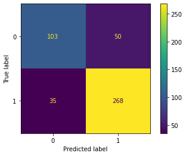

```python
plot_confusion_matrix(ADB_model,x_test,y_test);
```

#### Probability prediction for the training and test data

```python
# Training Data Probability Prediction
pred_prob_train = ADB_model.predict_proba(x_train)

# Test Data Probability Prediction
pred_prob_test = ADB_model.predict_proba(x_test)
```

```
AUC for the Training Data: 0.915
AUC for the Test Data: 0.877
```

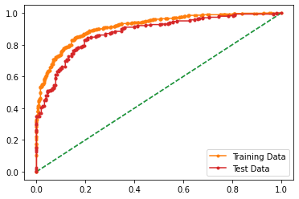

```python
# AUC and ROC for the training data

# calculate AUC
ADB_train_auc = metrics.roc_auc_score(y_train,pred_prob_train[:,1])
print('AUC for the Training Data: %.3f' % ADB_train_auc)

#  calculate roc curve
fpr, tpr, thresholds = metrics.roc_curve(y_train,pred_prob_train[:,1])
plt.plot([0, 1], [0, 1], linestyle='--')
# plot the roc curve for the model
plt.plot(fpr, tpr, marker='.',label = 'Training Data')


# AUC and ROC for the test data

# calculate AUC
ADB_test_auc = metrics.roc_auc_score(y_test,pred_prob_test[:,1])
print('AUC for the Test Data: %.3f' % ADB_test_auc)

#  calculate roc curve
fpr, tpr, thresholds = metrics.roc_curve(y_test,pred_prob_test[:,1])
plt.plot([0, 1], [0, 1], linestyle='--')
# plot the roc curve for the model
plt.plot(fpr, tpr, marker='.',label='Test Data')
# show the plot
plt.legend(loc='best')
plt.show()
```

#### Gradient Boosting

```python
from sklearn.ensemble import GradientBoostingClassifier
gbcl = GradientBoostingClassifier(random_state=1)
gbcl = gbcl.fit(x_train, y_train)
```

```python
## Performance Matrix on train data set
y_train_predict = gbcl.predict(x_train)
model_score = gbcl.score(x_train, y_train)
print(model_score)
print(metrics.confusion_matrix(y_train, y_train_predict))
print(metrics.classification_report(y_train, y_train_predict))
```

```
0.8925541941564562
[[239  68]
 [ 46 708]]
              precision    recall  f1-score   support

           0       0.84      0.78      0.81       307
           1       0.91      0.94      0.93       754

    accuracy                           0.89      1061
   macro avg       0.88      0.86      0.87      1061
weighted avg       0.89      0.89      0.89      1061
```

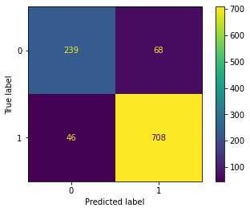

```python
plot_confusion_matrix(gbcl,x_train,y_train);
```

```python
## Performance Matrix on test data set
y_test_predict = gbcl.predict(x_test)
model_score = gbcl.score(x_test, y_test)
print(model_score)
print(metrics.confusion_matrix(y_test, y_test_predict))
print(metrics.classification_report(y_test, y_test_predict))
```

```
0.8355263157894737
[[105  48]
 [ 27 276]]
              precision    recall  f1-score   support

           0       0.80      0.69      0.74       153
           1       0.85      0.91      0.88       303

    accuracy                           0.84       456
   macro avg       0.82      0.80      0.81       456
weighted avg       0.83      0.84      0.83       456
```

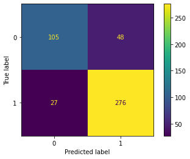

```python
plot_confusion_matrix(gbcl,x_test,y_test);
```

#### Probability prediction for the training and test data

```python
# Training Data Probability Prediction
pred_prob_train = gbcl.predict_proba(x_train)

# Test Data Probability Prediction
pred_prob_test = gbcl.predict_proba(x_test)
```

```
AUC for the Training Data: 0.951
AUC for the Test Data: 0.899
```

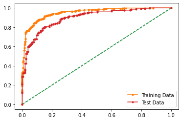

```python
# AUC and ROC for the training data

# calculate AUC
gbcl_train_auc = metrics.roc_auc_score(y_train,pred_prob_train[:,1])
print('AUC for the Training Data: %.3f' % gbcl_train_auc)

#  calculate roc curve
fpr, tpr, thresholds = metrics.roc_curve(y_train,pred_prob_train[:,1])
plt.plot([0, 1], [0, 1], linestyle='--')
# plot the roc curve for the model
plt.plot(fpr, tpr, marker='.',label = 'Training Data')


# AUC and ROC for the test data

# calculate AUC
gbcl_test_auc = metrics.roc_auc_score(y_test,pred_prob_test[:,1])
print('AUC for the Test Data: %.3f' % gbcl_test_auc)

#  calculate roc curve
fpr, tpr, thresholds = metrics.roc_curve(y_test,pred_prob_test[:,1])
plt.plot([0, 1], [0, 1], linestyle='--')
# plot the roc curve for the model
plt.plot(fpr, tpr, marker='.',label='Test Data')
# show the plot
plt.legend(loc='best')
plt.show()
```

## 1.7 Performance Metrics: Check the performance of Predictions on Train and Test sets using Accuracy, Confusion Matrix, Plot ROC curve and get ROC_AUC score for each model. Final Model: Compare the models and write inference which model is best/optimized.

### Comparison of Different Models

**Interest Class is 1 i.e) Voter_Labour = 1**

Let's look at the performance of all the models on the Train Data set </b>

Recall refers to the percentage of total relevant results correctly classified by the algorithm and hence we will compare Recall of class "1" for all models.

Logistic Regression - Recall for class "1" is 0.91 precision recall f1-score support

```
       0       0.75      0.64      0.69       307
       1       0.86      0.91      0.89       754

accuracy                           0.83      1061
```

macro avg 0.80 0.77 0.79 1061 weighted avg 0.83 0.83 0.83 1061

LDA - Recall for class "1" is 0.91 precision recall f1-score support

```
       0       0.74      0.65      0.69       307
       1       0.86      0.91      0.89       754

accuracy                           0.83      1061
```

macro avg 0.80 0.78 0.79 1061 weighted avg 0.83 0.83 0.83 1

KNN - Recall for class "1" is 0.92 precision recall f1-score support

```
       0       0.81      0.74      0.78       321
       1       0.89      0.92      0.91       740

accuracy                           0.87      1061
```

macro avg 0.85 0.83 0.84 1061 weighted avg 0.87 0.87 0.87 1061

Naive Bayes - Recall for class "1" is 0.90 precision recall f1-score support

```
       0       0.73      0.69      0.71       307
       1       0.88      0.90      0.89       754

accuracy                           0.84      1061
```

macro avg 0.80 0.79 0.80 1061 weighted avg 0.83 0.84 0.83 1061

DT model- Recall for class "1" is 0.91 precision recall f1-score support

```
       0       0.76      0.73      0.75       307
       1       0.89      0.91      0.90       754

accuracy                           0.86      1061
```

macro avg 0.83 0.82 0.82 1061 weighted avg 0.85 0.86 0.86 1061

RF model- Recall for class "1" is 0.94 precision recall f1-score support

```
       0       0.83      0.72      0.77       307
       1       0.89      0.94      0.92       754

accuracy                           0.88      1061
```

macro avg 0.86 0.83 0.84 1061 weighted avg 0.87 0.88 0.87 1061

Bagging model- Recall for class "1" is 0.99 precision recall f1-score support

```
       0       0.99      0.90      0.94       307
       1       0.96      0.99      0.98       754

accuracy                           0.97      1061
```

macro avg 0.97 0.95 0.96 1061 weighted avg 0.97 0.97 0.97 1061

Ada boosting - Recall for class "1" is 0.91 precision recall f1-score support

```
       0       0.76      0.70      0.73       307
       1       0.88      0.91      0.90       754

accuracy                           0.85      1061
```

macro avg 0.82 0.80 0.81 1061 weighted avg 0.85 0.85 0.85 1061

Gradient Boosting - Recall for class "1" is 0.94 precision recall f1-score support

```
       0       0.84      0.78      0.81       307
       1       0.91      0.94      0.93       754

accuracy                           0.89      1061
```

macro avg 0.88 0.86 0.87 1061 weighted avg 0.89 0.89 0.89 1061

**Compare test data**  
Logistic Regression - Recall for class "1" is 0.88

```
         precision    recall  f1-score   support

       0       0.75      0.72      0.74       153
       1       0.86      0.88      0.87       303

accuracy                           0.83       456
```

macro avg 0.81 0.80 0.80 456 weighted avg 0.83 0.83 0.83 456

LDA - Recall for class "1" is 0.89 precision recall f1-score support

```
       0       0.77      0.73      0.74       153
       1       0.86      0.89      0.88       303

accuracy                           0.83       456
```

macro avg 0.82 0.81 0.81 456 weighted avg 0.83 0.83 0.83 456

KNN model - Recall for class "1" is 0.89 precision recall f1-score support

```
       0       0.73      0.68      0.70       139
       1       0.86      0.89      0.88       317

accuracy                           0.82       456
```

macro avg 0.79 0.78 0.79 456 weighted avg 0.82 0.82 0.82 456

Naive Bayes - Recall for class "1" is 0.87 precision recall f1-score support

```
       0       0.74      0.73      0.73       153
       1       0.87      0.87      0.87       303

accuracy                           0.82       456
```

macro avg 0.80 0.80 0.80 456 weighted avg 0.82 0.82 0.82 456

DT model- Recall for class "1" is 0.87 precision recall f1-score support

```
       0       0.73      0.69      0.71       153
       1       0.85      0.87      0.86       303

accuracy                           0.81       456
```

macro avg 0.79 0.78 0.78 456 weighted avg 0.81 0.81 0.81 456

RF model- Recall for class "1" is 0.90 precision recall f1-score support

```
       0       0.77      0.67      0.72       153
       1       0.84      0.90      0.87       303

accuracy                           0.82       456
```

macro avg 0.81 0.79 0.79 456 weighted avg 0.82 0.82 0.82 456

Bagging model- Recall for class "1" is 0.90 precision recall f1-score support

```
       0       0.78      0.68      0.73       153
       1       0.85      0.90      0.88       303

accuracy                           0.83       456
```

macro avg 0.82 0.79 0.80 456 weighted avg 0.83 0.83 0.83 456

Ada boosting - Recall for class "1" is 0.88 precision recall f1-score support

```
       0       0.75      0.67      0.71       153
       1       0.84      0.88      0.86       303

accuracy                           0.81       456
```

macro avg 0.79 0.78 0.79 456 weighted avg 0.81 0.81 0.81 456

Gradient Boosting - Recall for class "1" is 0.91 precision recall f1-score support

```
       0       0.80      0.69      0.74       153
       1       0.85      0.91      0.88       303

accuracy                           0.84       456
```

macro avg 0.82 0.80 0.81 456 weighted avg 0.83 0.84 0.83 456

## 1.8 Based on these predictions, what are the insights?

Compare with all models based on the prediction, all are best fit except bagging model based on accuracy. Bagging is overfit model. We need to conclude and suggest one best model to solve the problem. Consider with other parameters of recall, F1 score and AUC. For true positive of recall prediction gradient boosting is best model.

**Insights and Recommendations**

1. As per the insights, Labours are maximum voters in dataset. Recommend that need to focus to increase the Conservative voters to increase the votes
2. Compare the voters with gender wise, females are maximum. Recommend that to focus to get more male voters to increase the votes.
3. In both labour and conservative, female voters is maximum. So, we can increase the votes by increasing male voters in both labour and conservative.

# Problem 2:

In this particular project, we are going to work on the inaugural corpora from the nltk in Python. We will be looking at the following speeches of the Presidents of the United States of America:

1. President Franklin D. Roosevelt in 1941
2. President John F. Kennedy in 1961
3. President Richard Nixon in 1973

### Import libraries and Extract the speeches:

```python
import nltk
nltk.download('punkt')
nltk.download('inaugural')
from nltk.corpus import inaugural
from nltk.tokenize import word_tokenize, sent_tokenize
```

```python
inaugural.fileids()
Roosevelt=inaugural.raw('1941-Roosevelt.txt')
Roosevelt
```

```
'On each national day of inauguration since 1789, the people have renewed their sense of dedication to the United States.\n\nIn Washington\'s day the task of the people was to create and weld together a nation.\n\nIn Lincoln\'s day the task of the people was to preserve that Nation from disruption f…
```

```python
Kennedy=inaugural.raw('1961-Kennedy.txt')
Kennedy
```

```
'Vice President Johnson, Mr. Speaker, Mr. Chief Justice, President Eisenhower, Vice President Nixon, President Truman, reverend clergy, fellow citizens, we observe today not a victory of party, but a celebration of freedom -- symbolizing an end, as well as a beginning -- signifying renewal, as well …
```

```python
Nixon=inaugural.raw('1973-Nixon.txt')
Nixon
```

```
'Mr. Vice President, Mr. Speaker, Mr. Chief Justice, Senator Cook, Mrs. Eisenhower, and my fellow citizens of this great and good country we share together:\n\nWhen we met here four years ago, America was bleak in spirit, depressed by the prospect of seemingly endless war abroad and of destructive c…
```

## 2.1 Find the number of characters, words, and sentences for the mentioned documents.

#### Roosevelt speech text analysis

```python
Roosevelt_characters=len(inaugural.raw('1941-Roosevelt.txt'))
Roosevelt_characters
```

```
7571
```

```python
Roosevelt_words=len(inaugural.words('1941-Roosevelt.txt'))
Roosevelt_words
```

```
1536
```

```python
Roosevelt_sentence=len(inaugural.sents('1941-Roosevelt.txt'))
Roosevelt_sentence
```

```
68
```

#### Kennedy speech text analysis

```python
Kennedy_characters=len(inaugural.raw('1961-Kennedy.txt'))
Kennedy_characters
```

```
7618
```

```python
Kennedy_words=len(inaugural.words('1961-Kennedy.txt'))
Kennedy_words
```

```
1546
```

```python
Kennedy_sentence=len(inaugural.sents('1961-Kennedy.txt'))
Kennedy_sentence
```

```
52
```

#### Nixon speech text analysis

```python
Nixon_characters=len(inaugural.raw('1973-Nixon.txt'))
Nixon_characters
```

```
9991
```

```python
Nixon_words=len(inaugural.words('1973-Nixon.txt'))
Nixon_words
```

```
2028
```

```python
Nixon_sentence=len(inaugural.sents('1973-Nixon.txt'))
Nixon_sentence
```

```
69
```

```python
index=['Characters', 'Words', 'Sentence']
dataf = pd.DataFrame({'Roosevelt':[Roosevelt_characters,Roosevelt_words,Roosevelt_sentence],
        'Kennedy':[Kennedy_characters,Kennedy_words,Kennedy_sentence],
       'Nixon':[Nixon_characters,Nixon_words,Nixon_sentence]},index=index)
round(dataf)
```

|  | Roosevelt | Kennedy | Nixon |
| --- | --- | --- | --- |
| Characters | 7571 | 7618 | 9991 |
| Words | 1536 | 1546 | 2028 |
| Sentence | 68 | 52 | 69 |

## 2.2 Remove all the stopwords from all three speeches.

#### Import libraries

```python
conda install -c r r-wordcloud
```

```
Solving environment: ...working... done

# All requested packages already installed.
```

```python
import nltk
nltk.download('stopwords')
```

```
True
```

```python
from nltk.corpus import stopwords
stopwordlist = stopwords.words('english')
stopwordlist.extend(["u", "let","know","america","wa", "ha", "still", "from"])
```

```python
len(stopwordlist)
```

```
187
```

### Make table for these 3 speeches

```python
index=['Roosevelt', 'Kennedy', 'Nixon']
speech = pd.DataFrame({'Text': [inaugural.raw('1941-Roosevelt.txt'), inaugural.raw('1961-Kennedy.txt'), inaugural.raw('1973-Nixon.txt')]}, index = index)
speech
```

|  | Text |
| --- | --- |
| Roosevelt | On each national day of inauguration since 178... |
| Kennedy | Vice President Johnson, Mr. Speaker, Mr. Chief... |
| Nixon | Mr. Vice President, Mr. Speaker, Mr. Chief Jus... |

### Basic Pre-Processing

Lower Case conversion:

```python
speech['processed_text'] = speech['Text'].apply(lambda x: ' '.join(x.lower() for x in x.split()))
```

```python
speech['processed_text']
```

```
Roosevelt    on each national day of inauguration since 178...
Kennedy      vice president johnson, mr. speaker, mr. chief...
Nixon        mr. vice president, mr. speaker, mr. chief jus...
Name: processed_text, dtype: object
```

#### Removal of Punctuation:

```python
speech['processed_text']=speech['processed_text'].str.replace('[^a-zA\s]', '')
speech['processed_text']
```

```
Roosevelt    on each national day of inauguration since  th...
Kennedy      vice president johnson mr speaker mr chief jus...
Nixon        mr vice president mr speaker mr chief justice ...
Name: processed_text, dtype: object
```

#### Use Lemmatizer to change the words to root form

```python
from nltk.stem import WordNetLemmatizer
nltk.download('wordnet')
```

```
True
```

```python
lemma = WordNetLemmatizer()
speech['processed_text'] = speech['processed_text'].apply(lambda x: ' '.join([lemma.lemmatize(x) for x in x.split()]))
```

```python
speech['processed_text']
```

```
Roosevelt    on each national day of inauguration since the...
Kennedy      vice president johnson mr speaker mr chief jus...
Nixon        mr vice president mr speaker mr chief justice ...
Name: processed_text, dtype: object
```

### Removal of StopWords

```python
speech['processed_text'] = speech['processed_text'].apply(lambda x: ' '.join(x for x in x.split() if x not in stopwordlist))
```

### Words count before and after the removal of stopwords

```python
index=['Words_count_before_stopword_removal', 'Words_count_after_stopword_removal']
wordscount = pd.DataFrame({'Roosevelt':[Roosevelt_words,len(word_tokenize(speech['processed_text'][0]))],
        'Kennedy':[Kennedy_words,len(word_tokenize(speech['processed_text'][1]))],
       'Nixon':[Nixon_words,len(word_tokenize(speech['processed_text'][2]))]},index=index)
round(wordscount)
```

|  | Roosevelt | Kennedy | Nixon |
| --- | --- | --- | --- |
| Words_count_before_stopword_removal | 1536 | 1546 | 2028 |
| Words_count_after_stopword_removal | 596 | 660 | 763 |

### Sample sentence after the removal of stopwords.

```python
sent_tokenize(speech['processed_text'][0])
```

```
['national day inauguration since people renewed sense dedication united state washington day task people create weld together nation lincoln day task people preserve nation disruption within day task people save nation institution disruption without come time midst swift happening pause moment take…
```

## 2.3 Which word occurs the most number of times in his inaugural address for each president? Mention the top three words. (after removing the stopwords)

#### Most frequent words finding

```python
Roosevelt_frequent_words=pd.Series(' '.join(word_tokenize(speech['processed_text'][0])).split()).value_counts()[:10]
Roosevelt_frequent_words
```

```
nation       15
life         11
democracy     9
people        9
spirit        9
year          7
freedom       6
human         5
men           5
mind          5
dtype: int64
```

```python
Kennedy_frequent_words=pd.Series(' '.join(word_tokenize(speech['processed_text'][1])).split()).value_counts()[:10]
Kennedy_frequent_words
```

```
side       8
world      8
power      7
new        7
nation     7
pledge     7
free       5
citizen    5
ask        5
shall      5
dtype: int64
```

```python
Nixon_frequent_words=pd.Series(' '.join(word_tokenize(speech['processed_text'][2])).split()).value_counts()[:10]
Nixon_frequent_words
```

```
peace             19
world             18
responsibility    16
new               15
nation            14
government        10
home               9
great              9
year               9
abroad             8
dtype: int64
```

In Roosevelt speech below words most frequently used  
nation - 15  
life - 11  
people, spirit, democracy - 9

In Nixon speech below words most frequently used  
peace - 19  
world - 18  
responsibility 16

## 2.4 Plot the word cloud of each of the speeches of the variable. (after removing the stopwords)

```python
!pip install wordcloud
```

```python
from wordcloud import WordCloud,STOPWORDS
import matplotlib.pyplot as plt
import seaborn as sns
```

### Word cloud for Roosevelt speech

```python
Rooseveltwords = ' '.join(word_tokenize(speech['processed_text'][0]))
Rooseveltcleanwords = " ".join([word for word in Rooseveltwords.split()])
```

```python
wordcloud_Roosevelt = WordCloud(stopwords=STOPWORDS,
                      width=3000,
                      height=2500
                     ).generate(Rooseveltcleanwords)
```

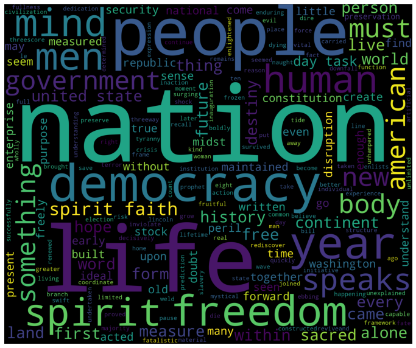

```python
plt.figure(figsize=(12, 12))
plt.imshow(wordcloud_Roosevelt)
plt.axis('off')
plt.show()
```

### Word cloud for Kennedy speech

```python
Kennedywords = ' '.join(word_tokenize(speech['processed_text'][1]))
Kennedycleanwords = " ".join([word for word in Kennedywords.split()])
```

```python
wordcloud_Kennedy = WordCloud(stopwords=STOPWORDS,
                      width=3000,
                      height=2500
                     ).generate(Kennedycleanwords)
```

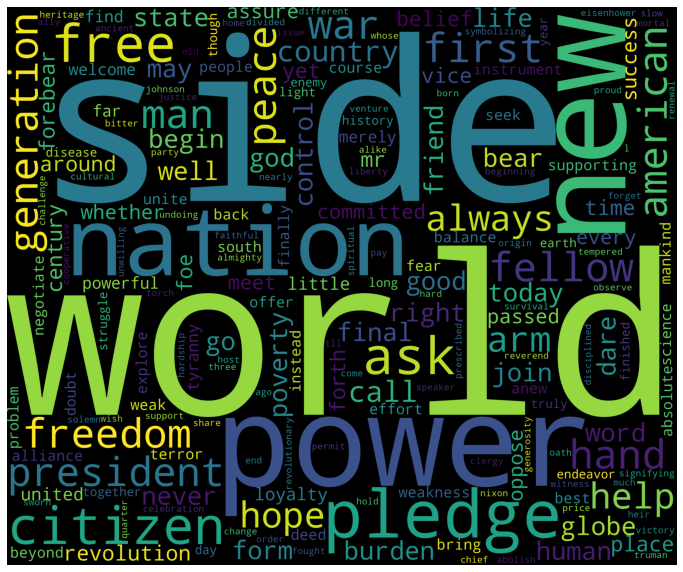

```python
plt.figure(figsize=(12, 12))
plt.imshow(wordcloud_Kennedy)
plt.axis('off')
plt.show()
```

### Word cloud for Nixon speech

```python
Nixonwords = ' '.join(word_tokenize(speech['processed_text'][2]))
Nixoncleanwords = " ".join([word for word in Nixonwords.split()])
```

```python
wordcloud_Nixon = WordCloud(stopwords=STOPWORDS,
                      width=3000,
                      height=2500
                     ).generate(Nixoncleanwords)
```

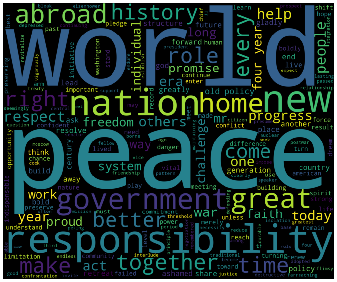

```python
plt.figure(figsize=(12, 12))
plt.imshow(wordcloud_Nixon)
plt.axis('off')
plt.show()
```